# Clustering et dendrogramme, méthodes distance au centroïde

Chargement de l'environnement de travail

```r
library('sf')
library('units')
library('rpostgis')
library('tidyverse')
library('RColorBrewer')
library('htmlwidgets')
library('IRdisplay')
library('alphahull')
library('igraph')
library('leaflet')
library('beepr.kaamelott')
```

Connexion à la BD et affichage du sous-ensemble test

```r
conn <- dbConnect("PostgreSQL", dbname = 'essai_clus', host = 'localhost', user = 'postgres', password = '$asd$')
```

```r
bgs <- st_read(conn, query = "SELECT * FROM indic_bldg WHERE ST_Intersects(geom, ST_SetSRID(ST_GeomFromText('Polygon((535750 153400, 535750 156000, 538400 156000, 538400 153400, 535750 153400))'), 21781));")
bgs <- st_zm(bgs, drop = T)
n_bgs <- nrow(bgs)
plot(bgs$geom, main = paste("Aperçu du subset (", n_bgs, " bats)", sep = ""), col = 'gray93', border = "gray80")
```

[output not shown]

Préparation des `df` pour calcul des distances

```r
bgs_test <- bgs %>%
            remove_rownames() %>%
            column_to_rownames('id')
bgs_data_test <- bgs_test %>%
                st_set_geometry(NULL)
```

```r
att_d_m <- as.data.frame(as.matrix(dist(scale(bgs_data_test[, c(-31:-34, -36:-39)]))))
head(att_d_m)

spa_d_m <- as.data.frame(st_distance(bgs_test))

rownames(spa_d_m) <- colnames(spa_d_m) <- rownames(att_d_m)

head(spa_d_m)
```

|  | 47242 | 47287 | 49028 | 49033 | 49037 | 49042 | 49080 | 49084 | 49089 | 49123 | ... | 61377 | 61378 | 61380 | 51526 | 60767 | 60764 | 15747 | 61120 | 30511 | 49704 |
| --- | --- | --- | --- | --- | --- | --- | --- | --- | --- | --- | --- | --- | --- | --- | --- | --- | --- | --- | --- | --- | --- |
| 47242 | 0.000000 | 4.434257 | 1.687410 | 4.571279 | 3.895067 | 3.624876 | 3.3145655 | 3.207881 | 5.047275 | 4.377376 | ... | 5.921664 | 6.908671 | 4.276444 | 36.68217 | 53.52320 | 28.66210 | 9.977545 | 8.487867 | 4.953029 | 4.205004 |
| 47287 | 4.434257 | 0.000000 | 4.670545 | 4.245345 | 5.428504 | 4.717196 | 4.9404755 | 4.430664 | 4.694481 | 3.794676 | ... | 2.561333 | 7.852112 | 5.116040 | 35.68150 | 52.50525 | 27.71016 | 8.675760 | 6.363757 | 4.337444 | 4.024673 |
| 49028 | 1.687410 | 4.670545 | 0.000000 | 3.951053 | 2.438285 | 3.429476 | 1.8986129 | 2.760745 | 4.312971 | 4.285920 | ... | 6.092801 | 6.423148 | 2.955442 | 36.29876 | 53.29177 | 28.20758 | 9.838053 | 8.434563 | 4.913071 | 4.291731 |
| 49033 | 4.571279 | 4.245345 | 3.951053 | 0.000000 | 3.353807 | 4.486169 | 2.9677976 | 2.817309 | 1.858878 | 1.991064 | ... | 5.191460 | 6.657467 | 2.643933 | 36.62297 | 53.66831 | 28.51592 | 10.958972 | 8.953946 | 3.202795 | 2.433013 |
| 49037 | 3.895067 | 5.428504 | 2.438285 | 3.353807 | 0.000000 | 4.794106 | 0.7637453 | 2.556817 | 3.983537 | 4.719117 | ... | 6.383437 | 5.481833 | 1.982343 | 35.51900 | 52.69680 | 27.31325 | 9.888651 | 8.600949 | 5.517321 | 4.319746 |
| 49042 | 3.624876 | 4.717196 | 3.429476 | 4.486169 | 4.794106 | 0.000000 | 4.3499306 | 5.207998 | 3.616413 | 3.725893 | ... | 6.717709 | 9.336422 | 3.618320 | 37.54245 | 54.50510 | 29.65561 | 11.476828 | 9.317899 | 3.021804 | 5.531448 |

|  | 47242 | 47287 | 49028 | 49033 | 49037 | 49042 | 49080 | 49084 | 49089 | 49123 | ... | 61377 | 61378 | 61380 | 51526 | 60767 | 60764 | 15747 | 61120 | 30511 | 49704 |
| --- | --- | --- | --- | --- | --- | --- | --- | --- | --- | --- | --- | --- | --- | --- | --- | --- | --- | --- | --- | --- | --- |
| 47242 | 0.0000 m | 190.6156 m | 2503.6404 m | 2177.9247 m | 2285.9597 m | 2667.8105 m | 2276.91371 m | 2396.4661 m | 2467.9057 m | 1601.8823 m | ... | 564.8588 m | 636.1375 m | 711.3546 m | 1724.090 m | 1869.8990 m | 1844.7058 m | 2298.3259 m | 372.1432 m | 2233.0895 m | 1220.702 m |
| 47287 | 190.6156 m | 0.0000 m | 2699.6522 m | 2389.0612 m | 2457.7932 m | 2864.2576 m | 2451.20771 m | 2579.8237 m | 2667.4031 m | 1814.1900 m | ... | 754.3702 m | 848.2035 m | 919.1514 m | 1781.689 m | 2077.5326 m | 2056.9925 m | 2491.0826 m | 284.5761 m | 2345.1218 m | 1411.429 m |
| 49028 | 2503.6404 m | 2699.6522 m | 0.0000 m | 687.3125 m | 579.3918 m | 137.9603 m | 539.98261 m | 317.4713 m | 101.9869 m | 1084.6392 m | ... | 2227.2476 m | 1941.9983 m | 1980.1271 m | 1965.070 m | 574.7542 m | 829.5292 m | 184.2217 m | 2634.6091 m | 1493.2134 m | 1990.560 m |
| 49033 | 2177.9247 m | 2389.0612 m | 687.3125 m | 0.0000 m | 1100.2261 m | 780.5549 m | 1054.86613 m | 914.2070 m | 571.4224 m | 568.4706 m | ... | 1773.8741 m | 1527.3604 m | 1527.8972 m | 2200.989 m | 176.3204 m | 223.3105 m | 671.0865 m | 2405.5100 m | 1922.8471 m | 1389.174 m |
| 49037 | 2285.9597 m | 2457.7932 m | 579.3918 m | 1100.2261 m | 0.0000 m | 684.3964 m | 14.59226 m | 234.9603 m | 667.5797 m | 1228.3383 m | ... | 2147.9965 m | 1848.0907 m | 1922.8367 m | 1394.714 m | 841.8400 m | 1113.5361 m | 402.0811 m | 2327.6808 m | 882.2599 m | 2092.712 m |
| 49042 | 2667.8105 m | 2864.2576 m | 137.9603 m | 780.5549 m | 684.3964 m | 0.0000 m | 649.07022 m | 420.1628 m | 209.6764 m | 1226.6468 m | ... | 2384.5641 m | 2101.1259 m | 2136.5945 m | 2095.424 m | 707.6619 m | 950.8676 m | 343.4101 m | 2799.4372 m | 1592.1171 m | 2127.873 m |

Fonction pour calculer l'appartenance d'un bâtiment à un cluster en fonction d'un seuil attributaire et spatial

```r
clus_bdg <- function(sfdf, scaled, fd, sd, mda = 0, mds = 0) {

   if(nrow(mda) & nrow(mds)) {
    adm <- mda
    sdm <- mds
   } else {
        # Préparation et séparation des données (non-)spatiales
    bgs_1 <- sfdf %>%
                remove_rownames() %>%
                column_to_rownames('id')
    bgs_data_1 <- bgs_1 %>%
                    st_set_geometry(NULL)

    # Calcul des matrices de distance
    adm <- if(scaled) {
                as.data.frame(as.matrix(dist(bgs_data_1[, c(-31:-34, -36:-39)]))) #### !!!!!! A CHANGER PAR LA SUITE
            } else {
                as.data.frame(as.matrix(dist(scale(bgs_data_1[, c(-31:-34, -36:-39)]))))
            }
    sdm <- st_distance(bgs_1)
    rownames(sdm) <- colnames(sdm) <- rownames(adm)
   }

    # Préparation df résultats
    final_clus <- as.data.frame(cbind(rownames(adm), integer(length(nrow(sdm)))), stringsAsFactors = F)
        colnames(final_clus) <- c('id', 'clus') # Rename col

        # Return a df with all bdgs still to class
        remaining_rows <- function(df_clus) {

        r_rows <- df_clus %>%
                    filter(clus == 0)
        return(r_rows)
    }

    # Retrieve the first round of neighbours for the given building
    find_first_nbrs <- function(bat_id, attdm, spadm) {

        df_bat <- as.data.frame(cbind(adm[,bat_id], sdm[,bat_id])) # Distances to every bdg
        colnames(df_bat) <- c('dist_att', 'dist_spat') # Rename col
        df_bat$id <- rownames(sdm) # Add a col w/ ids
        near_bdgs_id <- df_bat %>%
                            filter(dist_att <= fd & dist_spat <= sd & id != bat_id) %>% # Bds under threshold, except the origin
                            pull(id) # return the column as a vector

        return(near_bdgs_id)
    }

    find_nbrs_of_nbrs <- function(nbrs_id) {
        n_id <- character() # Create empty vector for ids

        for(bdg in nbrs_id) {
            df_bat_n <- as.data.frame(cbind(adm[,bdg], sdm[,bdg])) # Distances to every bdg
            colnames(df_bat_n) <- c('dist_att', 'dist_spat') # Rename col
            df_bat_n$id <- rownames(sdm) # Add a rowname column
            near_bdgs_n <- df_bat_n %>%
                               filter(dist_att <= fd & dist_spat <= sd & id != bdg)
            n_id <- c(n_id, near_bdgs_n$id) # Add new neighIDs to the vector of all id
        }

        return(unique(n_id)) # Return only the unique neighbours
    }

    cluster <- function(id_bd, cls_nb) {
        nbrs <- find_first_nbrs(id_bd, adm, sdm) # Trouve les voisins du premier id
        prev_lgt <- prev_lgt_nbrs <- 0 # Initialise les longueurs précédentes à zéro
        unique_ids <- append(id_bd, nbrs) # Créée le vecteur d'ids unique avec l'id donné et les premiers voisins

        for (i in 1:10000) {
            a <- find_nbrs_of_nbrs(nbrs) # Trouver les voisins des voisins

            if(!(length(a))) { # Si pas de voisin
                final_clus[final_clus$id == id_bd, 'clus'] <<- cls_nb # Assigne l'id comme cluster
                break # Sort de la boucle

            } else if(length(a) == prev_lgt | length(unique(unique_ids)) == prev_lgt_nbrs) { # Si autant de voisins qu'à l'itération précédente

                for(j in unique(unique_ids)) { # Assigne aux voisins l'id du 1er batiment
                    final_clus[final_clus$id == j, 'clus'] <<- cls_nb
                }
                break # Sort de la boucle
            }
            prev_lgt_nbrs <- length(unique(unique_ids)) # Ajuste la longueur précédente des ids uniques
            unique_ids <- append(unique_ids, a) # Ajoute les ids à la liste

            prev_lgt <- length(a) # Ajuste la longueur précédente des voisins
            nbrs <- a # Assigne nbrs pour la prochaine itération
        }
    }

    for(i in final_clus$id) {
        if(i %in% remaining_rows(final_clus)$id) {
            cluster(i, i)
        }
    }

    final_clus$cls <- as.factor(as.integer(as.factor(final_clus$clus)))
    final_clus$clus <- NULL

    return(final_clus)

}
```

Préparation des données pour obtenir un tableau des clusters à différents seuils

```r
bgs_ids <- as.data.frame(bgs$id)
```

```r
Sys.time()
for(i in seq(1, 7, 0.5)) {
        bgs_ids <- cbind(bgs_ids, clus_bdg(bgs_1, F, i, 100, att_d_m, spa_d_m)$cls)
        colnames(bgs_ids)[ncol(bgs_ids)] <- paste0('cls_', i, '_', 100)
    }
Sys.time()
```

```
[1] "2018-11-12 09:07:24 CET"
```

```
[1] "2018-11-12 09:14:14 CET"
```

```r
bgs_ids <- bgs_ids %>%
            column_to_rownames('bgs$id')
```

```r
head(bgs_ids)
```

|  | cls_1_100 | cls_1.5_100 | cls_2_100 | cls_2.5_100 | cls_3_100 | cls_3.5_100 | cls_4_100 | cls_4.5_100 | cls_5_100 | cls_5.5_100 | cls_6_100 | cls_6.5_100 | cls_7_100 |
| --- | --- | --- | --- | --- | --- | --- | --- | --- | --- | --- | --- | --- | --- |
| 47242 | 207 | 146 | 112 | 94 | 78 | 56 | 44 | 34 | 27 | 22 | 16 | 15 | 10 |
| 47287 | 209 | 148 | 114 | 96 | 80 | 56 | 44 | 34 | 27 | 22 | 16 | 15 | 10 |
| 49028 | 283 | 197 | 156 | 132 | 108 | 78 | 59 | 34 | 27 | 22 | 16 | 15 | 10 |
| 49033 | 287 | 201 | 159 | 134 | 108 | 78 | 59 | 34 | 27 | 22 | 16 | 15 | 10 |
| 49037 | 289 | 203 | 160 | 135 | 110 | 78 | 59 | 34 | 27 | 22 | 16 | 15 | 10 |
| 49042 | 291 | 197 | 156 | 132 | 108 | 78 | 59 | 34 | 27 | 22 | 16 | 15 | 10 |

```r
beep.kaamelott(24)
```

Copie des `df` pour pouvoir les joindre afin d'effectuer des tests par la suite

```r
bgs_ids_2 <- bgs_ids %>%
            rownames_to_column('id')
```

```r
bgs_test_2 <- bgs_test %>%
                rownames_to_column('id')
```

```r
test <- merge(bgs_test_2, bgs_ids_2)
```

### Suite

#### Distance spatiale entre clusters et enveloppes géométriques

`test` est un sfdf avec les attributs, géométries et clusters d'attribution

Ainsi, pour chaque seuil, il est possible de connaître le centroide de l'enveloppe concave ($\alpha$-shape ou $\alpha$-hull) des clusters. Toutefois, plusieurs problèmes se posent:

- Les clusters avec peu de bâtiments $\Rightarrow$ utiliser les noeuds des polygones résout le problème: Ne garder que les bâtiments du cluster sélectionné, transformer les noeuds en points, extraire leur coordonnées et ne garder que les coordonnées uniques

  ```
  unique(st_coordinates(st_cast(filter(test, as.numeric(cls_3_100) == id_clus)$geom, 'POINT')))
  ```

- La définition de l'$\alpha$, cela peut donner des résultats assez différents, en fonction du nombre de bâtiments du cluster et de leur disposition. Il faut également enregistrer, pour chaque cluster, le polygone correspondant à l'$\alpha$-shape afin de l'utiliser (ou son centroïde) ultérieurement.

  ```
  Voir code ci-dessous
  ```

```r
#st_write(test, 'couche_interm.gpkg', driver = 'GPKG')
```

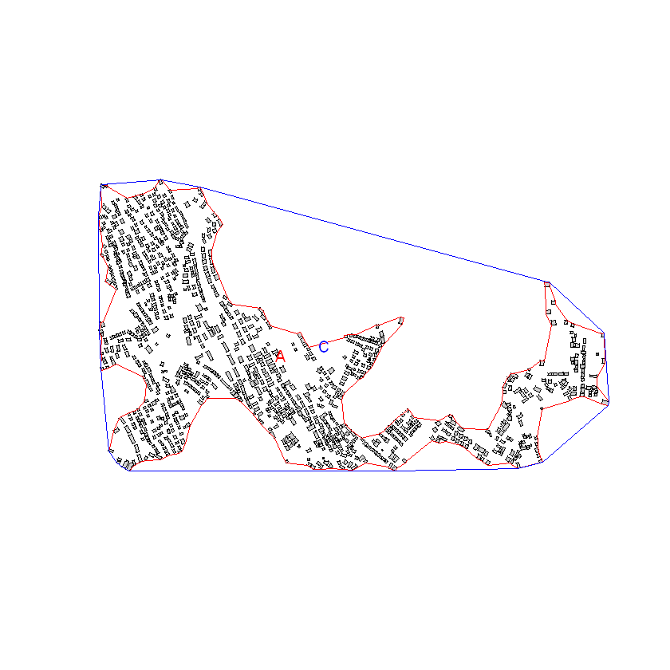

```r
ex_pol_from_ashape <- unique(st_coordinates(st_cast(filter(test, as.numeric(cls_3_100) == 108)$geom, 'POINT')))
ex_shape <- ashape(ex_pol_from_ashape, alpha = 100)

# Créer un graphe à partir des edges de l'ashape
tcirctest <- cbind(as.character(ex_shape$edges[, "ind1"]), as.character(ex_shape$edges[,
    "ind2"]))
tcirc <- graph.edgelist(cbind(as.character(ex_shape$edges[, "ind1"]), as.character(ex_shape$edges[,
    "ind2"])), directed = FALSE)
# Enlever une des edges du graphe
cutg = tcirc - E(tcirc)[1]
# Trouver le dernier noeud et créer la suite
ends = names(which(degree(cutg) == 1))
path = get.shortest.paths(cutg, ends[1], ends[2])[[1]]
# Index des points
pathX = as.numeric(names(unlist(path)))
# Rajout du premier point pour fermer le polygone
pathX = c(pathX, pathX[1])

heho <- NULL
for(i in pathX) {
    heho <- rbind(heho, ex_shape$x[i,])
}

p <- st_sfc(st_polygon(list(heho)), crs = 21781)

plot(filter(test, as.numeric(cls_3_100) == 108)$geom, col = 'lightgrey')
plot(st_cast(filter(test, as.numeric(cls_3_100) == 108)$geom, 'POINT'), pch = '.', add= T)
plot(p, add = T, border = 'red')
plot(st_centroid(p), pch = 'A', col = 'red', add = T)
plot(st_convex_hull(st_union(filter(test, as.numeric(cls_3_100) == 108)$geom)), border = 'blue', add = T)
plot(st_centroid(st_convex_hull(st_union(filter(test, as.numeric(cls_3_100) == 108)$geom))), pch = 'C', col = 'blue', add = T)
```

#### Distances attributaires

Pour les distances attributaires, on sélectionne les colonnes qui nous intéressent, ainsi que le seuil étudié. Ensuite les bâtiments sont regroupés par cluster (créée des multipolygones avec les polygones) et les différents indicateurs sont moyennés.

```r
a <- test %>%
        select(c(-1,-32:-35, -37:-53), cls_3_100) %>%
        group_by(cls_3_100) %>%
        summarise_all(mean)
head(a)
```

[output not shown]

[output cut: 157 more lines]

[output not shown]

#### Coordonnées des centroïdes de polygones ou de l'enveloppe concave en cas de multipolygones

Cette fonction prend en entrée le dataframe des attributs moyens des clusters et joint les coordonnées du centroïde du polygone (1 bâtiment) ou de l'enveloppe concave (2 ou plus bâtiments) en sortie.

```r
get_centroid <- function(cls_attr_df) {

    coords <- data.frame() # Un nouveau dataframe vide

    for(i in 1:nrow(cls_attr_df)) {
        row <- cls_attr_df[i, ] # Le cluster (rang) en cours

        if(st_geometry_type(row) == 'MULTIPOLYGON') { # S'il y a plusieurs bâtiments
            # Récupère les coordonnées uniques des vertices des polygones de bâtiments
            ex_pol_from_ashape <- unique(st_coordinates(st_cast(st_sfc(row$geometry, crs = 21781), 'POINT', group_or_split = T)))
            # Créée l'alphashape sur la base des points précédents. Ici alpha = 100
            ex_shape <- ashape(ex_pol_from_ashape, alpha = 100)

            # Créer un graphe à partir des edges de l'ashape
            tcirc <- graph.edgelist(cbind(as.character(ex_shape$edges[, "ind1"]), as.character(ex_shape$edges[,
                "ind2"])), directed = FALSE)
            # Enlever une des edges du graphe
            cutg = tcirc - E(tcirc)[1]
            # Trouver le dernier noeud et créer la suite
            ends = names(which(degree(cutg) == 1))
            path = get.shortest.paths(cutg, ends[1], ends[2])[[1]]
            # Index des points
            pathX = as.numeric(names(unlist(path)))
            # Rajout du premier point pour fermer le polygone
            pathX = c(pathX, pathX[1])

            coords_poly <- NULL

            for(i in pathX) { # Récupérer les points dans le bon ordre
                coords_poly <- rbind(coords_poly, ex_shape$x[i,])
            }
            # Créer le polygone (ashape) sur la base des coordonnées récupérées
            p <- st_sfc(st_polygon(list(coords_poly)), crs = 21781)

            # Rajouter les coordonnées du centroïdes (x et y) au df temporaire
            coords <- rbind(coords, st_coordinates(st_centroid(p)))

        } else {
            # Rajouter les coordonnées du centroïde (x et y) du bâtiment au df temporaire
            coords <- rbind(coords, st_coordinates(st_centroid(row$geometry)))
        }

    }

    # Joindre les coordonnées x et y
    cd_centro <- apply(coords, 1, function(x) {

        paste(round(x[1], 2), round(x[2], 2), sep = ',')
    })

    return(cbind(cls_attr_df, cd_centro))
}
```

```r
b <- a
waza <- get_centroid(b)
head(waza)
```

[output not shown]

```r
zzz <- waza %>%
        select(-cd_centro)

rownames(zzz) <- NULL

zzz <- zzz %>%
        column_to_rownames('cls_3_100') %>%
        st_set_geometry(NULL)
```

```r
what <- hclust(dist(scale(zzz)))
```

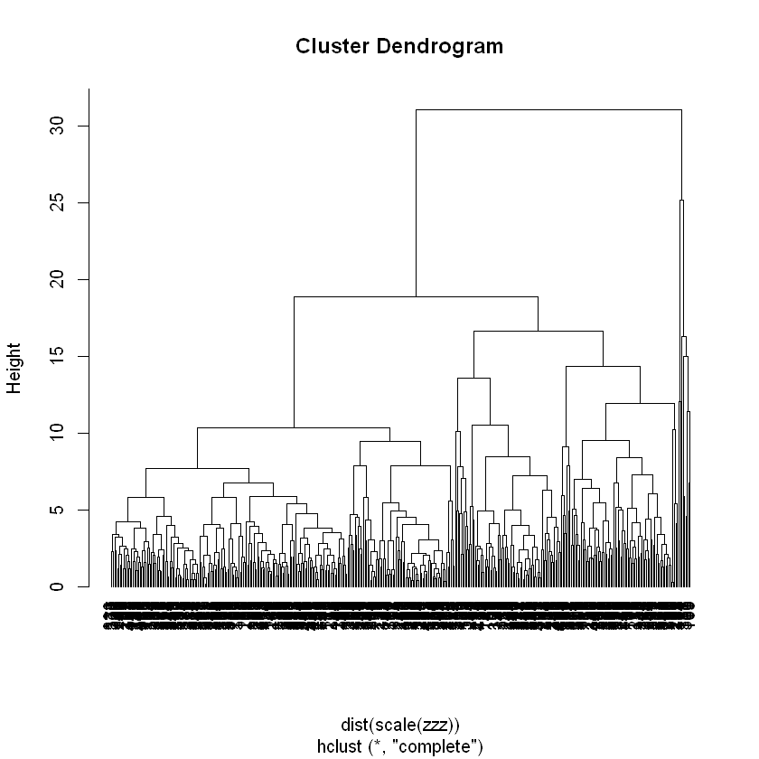

```r
plot(what, hang = -1)
```

```r
hhhh_10 <- cutree(what, h = 10)
```

```r
waza_cls <- cbind(waza, hhhh_10)
```

```r
st_write(waza_cls, 'Clustering_7_rslt_dendro_dist_eucld_h10.gpkg', driver = 'GPKG')
```

```
Writing layer `Clustering_7_rslt_dendro_dist_eucld_h10' to data source `Clustering_7_rslt_dendro_dist_eucld_h10.gpkg' using driver `GPKG'
features:       410
fields:         34
geometry type:  Unknown (any)
```